# The Cook Book of Data Processing in TLR Project

## 1. Introduction

This document mainly notes how did we do the computational work from the raw dataset downloaded from the Internet. This document denotes how to get the dataset from the website, the data processing steps, how to detect repeat units and some ideas from the result.

In this project, programs 'FFAS' and 'FAIT' are in the cluster: Godziklab/shared/FAIT_1. The document share the code about how to preprocess input data and analysis the results.

## 2. Obtain Data

In this project, we download the TLR and NLR protein sequences from the website: Gnsemblgenomes (http://ensemblgenomes.org/info/genomes?division=2) to get the protein sequences of 'Strongylocentrotus purpuratus'. We download the dataset and name it as 'Strongylocentrotus_purpuratus.Spur_3.1.pep.all.fa'.

## 3. DATA Processing

'Strongylocentrotus_purpuratus.Spur_3.1.pep.all.fa' denotes different kinds of protein sequences in Sea Urchin and we are interested in TLR and NLR proteins. Therefore, we need to select these two kinds of protein from the whole dataset.

For the initial dataset, we need to do several processing steps:

1. Stelect TLR and NLR from the dataset. (This step is made using bash)

```python
# !/bin/bash
# This code is help us extract TLR and NLR sequences from .fa file

awk '/^>/ { p = ($0 ~ /TLR/)} p' Strongylocentrotus_purpuratus.Spur_3.1.pep.all.fa > Strongylocentrotus_TLR.fa

echo The number of TLR in Stronglocentrotus is
grep -c "^>" Strongylocentrotus_TLR.fa


awk '/^>/ { p = ($0 ~ /NLR/)} p' Strongylocentrotus_purpuratus.Spur_3.1.pep.all.fa > Strongylocentrotus_NLR.fa

echo The number of NLR in Stronglocentrotus is
grep -c "^>" Strongylocentrotus_NLR.fa
```

Save the bash code as select.bash then run the code and we can get two files which note the TLR sequences and NLR sequences: 'Strongylocentrotus_TLR.fa' and 'Strongylocentrotus_NLR.fa'.

```python
./select.bash
```

As program 'FAIT' deals with one sequence at one time, we need to export TLR and NLR sequences into individual files (i.e. one sequences in one file): In this step, we can use the function in Python package 'Biopython' and the code is from the website https://www.biostars.org/p/273248/.

```python
# This code is used to split the multiple sequences into a sequence file.
from Bio import SeqIO
import argparse

parser = argparse.ArgumentParser(description="Split the fasta file into individual file with each gene seq")
parser.add_argument('-f', action='store', dest='fasta_file', help='Input fasta file')
result = parser.parse_args()

f_open = open(result.fasta_file, "rU")

for rec in SeqIO.parse(f_open, "fasta"):
   id = rec.id
   seq = rec.seq
   id_file = open(id, "w")
   id_file.write(">"+str(id)+"\n"+str(seq))
   id_file.close()

f_open.close()
```

To run above code, (save the above code in split.py file)

```python
python split.py -f Strongylocentrotus_TLR.fa
```

```python
python split.py -f Strongylocentrotus_NLR.fa
```

Then we can get the splited seuqneces, the file name will be the sequence's name. These sequence files are the input data for FFAS and FAIT.

## 4. Run FFAS and FAIT

In this section, we need to firstly run FFAS and then use FAIT to detect the repeat units in each sequence. The source code is on the UCR biocluster: Godziklab/shared/FAIT_1. We can copy the sequence files into the directory: 'Godziklab/shared/FAIT_1/sequences_1' and then run the code:

```python
./loop.sh
```

The outputs are in directory 'Godziklab/shared/FAIT_1/sequences_1/out'. Based on the output, we can collect the results and do the analysising job. It will be in next section.

## 5. Statistics of Results

Based on the results, we collect the information of repeat units in each sequence and make the table to denote the these features.

The table four columns: Sequence ID, Units Number, Units Length and Variance. The following code is help us to grab these features and make the table.

```python
import re
import numpy as np
import glob
import pandas as pd
```

```python
path = 'Godziklab/shared/FAIT_1/sequences_1/out/*-tr.txt'
files=glob.glob(path)
summary = pd.DataFrame()
for file in files:
    ID = file[3:len(file)-7]
    f = open(file,'r')
    s = f.read()
    result = re.findall("UnitLength=\"(\d+)\"",s)
    result = list(map(int, result))
    variance = round(np.var(result),2)
    unit_number = round(len(result),2)
    average_length = round(sum(result)/len(result),2)
    data = [ID, unit_number, variance, average_length]
    df = pd.DataFrame(data)
    summary = pd.concat([summary,df], axis = 1, ignore_index = True)

    f.close()
```

```python
summary = summary.T
summary.columns = ['ID', 'unit_number', 'variance','average_length']
```

```python
summary.to_csv('summary.txt', header=True, index=False, sep='\t', mode='a')
```

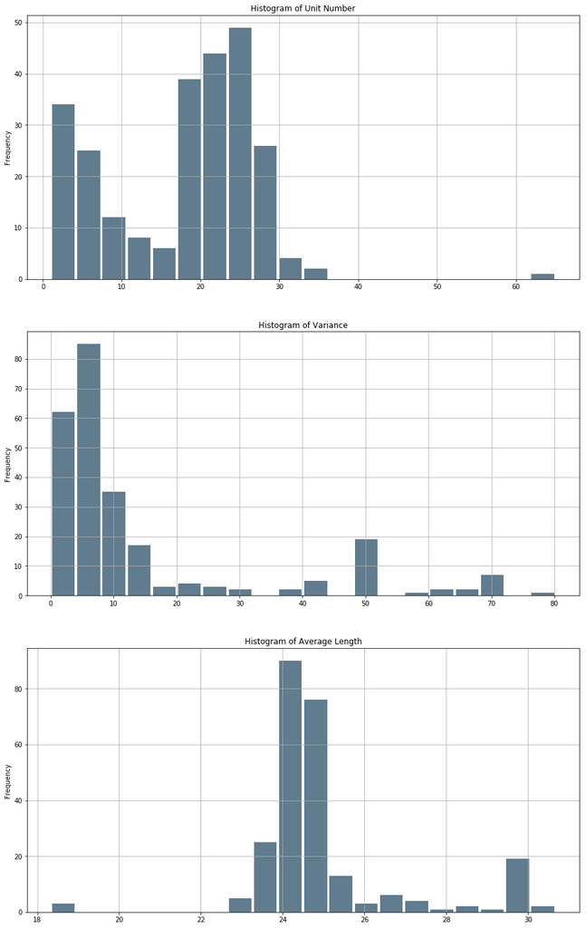

```python
# Import the libraries
import matplotlib.pyplot as plt
import numpy as np

fig = plt.figure(figsize=(15,25))

# Divide the figure into a 2x1 grid, and give me the first section
ax1 = fig.add_subplot(311)

# Divide the figure into a 2x1 grid, and give me the second section
ax2 = fig.add_subplot(312)

# Divide the figure into a 3x1 grid, and give me the second section
ax3 = fig.add_subplot(313)

summary['unit_number'].plot.hist(grid=True, bins=20, rwidth=0.9, ax = ax1, color='#607c8e')
ax1.set_title("Histogram of Unit Number")
summary['variance'].plot.hist(grid=True, bins=20, rwidth=0.9, ax = ax2, color='#607c8e')
ax2.set_title("Histogram of Variance")
summary['average_length'].plot.hist(grid=True, bins=20, rwidth=0.9, ax = ax3, color='#607c8e')
ax3.set_title("Histogram of Average Length")
```

Then we want to see the corrleation between each two columns

```python
summary['unit_number'] = summary['unit_number'].astype(float)
summary['variance'] = summary['variance'].astype(float)
summary['average_length'] = summary['average_length'].astype(float)
```

We can also get the correlation with each two column in ['unit_number','variance','average_length']

```python
summary[['unit_number','variance','average_length']].corr()
```

|  | unit_number | variance | average_length |
| --- | --- | --- | --- |
| unit_number | 1.000000 | -0.646233 | -0.473714 |
| variance | -0.646233 | 1.000000 | 0.743185 |
| average_length | -0.473714 | 0.743185 | 1.000000 |

Then we can make the 3D plot

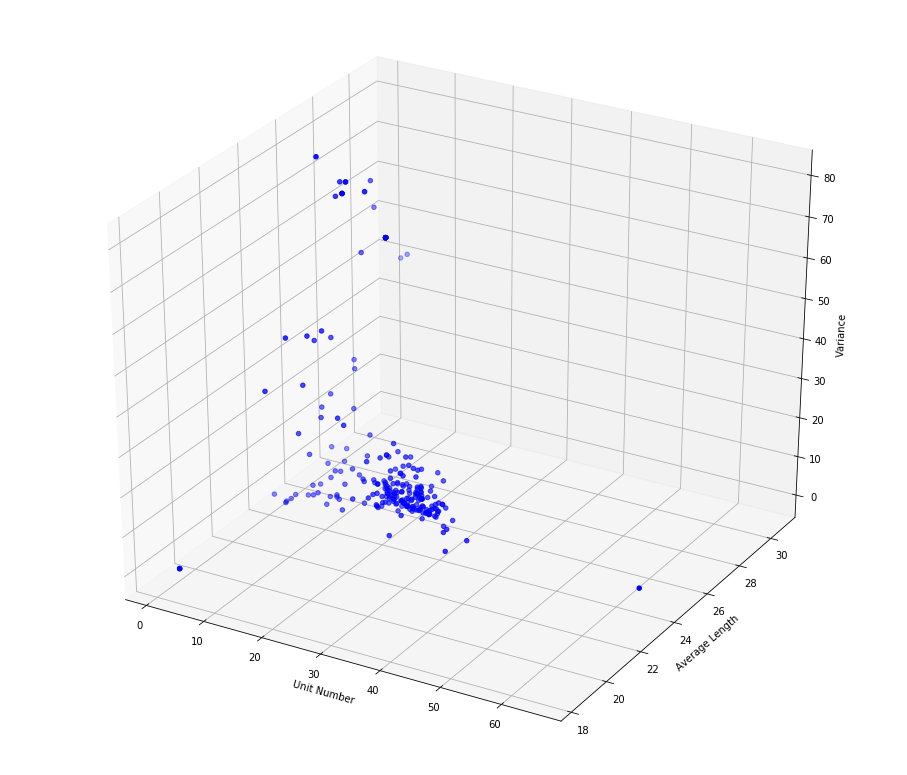

```python
from mpl_toolkits.mplot3d import Axes3D
import matplotlib.pyplot as plt


fig = plt.figure(figsize=(16,14))
ax = fig.add_subplot(111, projection='3d')

ax.scatter(summary['unit_number'], summary['average_length'], summary['variance'], c='b', marker='o')

ax.set_xlabel('Unit Number')
ax.set_ylabel('Average Length')
ax.set_zlabel('Variance')

plt.show()
```

From the result, we can see some of them show the small unit number but large variance. That is uncorrect based on the study od protein. In order to see what happened for that proteins, we what to see the results of repeat units

```python
from Bio import SeqIO
fasta_sequences = SeqIO.parse(open('../input_sequences/SPU_001862-tr'),'fasta')
for fasta in fasta_sequences:
        name, sequence = fasta.id, str(fasta.seq)
print(sequence)
```

```
LAIIGYQEITENQGPMDYEYQLNLMFREDDEWWINDCMKPFLQGRMPHLEHIVFGDNGLHPGSFYLNAIYDVIENSYKTVLLLSNQSVEDTWFMTKLRMAVEHMNDTKLEKVILIFLEDVDDDHLPYLVRLLLSRNKPYLLWVDDDEDGQELFWAKFEKSMRANREMNNVIPV
```

```python
SPU_009343_repeat_units = [[36,58],[58,95],[95,127],[127,143]]
for i in range(0, 4):
    print('repeat:', i )
    print(sequence[SPU_009343_repeat_units[i][0]:SPU_009343_repeat_units[i][1]])
```

```
repeat: 0
CMKPFLQGRMPHLEHIVFGDNG
repeat: 1
LHPGSFYLNAIYDVIENSYKTVLLLSNQSVEDTWFMT
repeat: 2
KLRMAVEHMNDTKLEKVILIFLEDVDDDHLPY
repeat: 3
LVRLLLSRNKPYLLWV
```

*We see the main error mainly because the input sequences are too short.* Therefore, we are going to select the correct sequences.

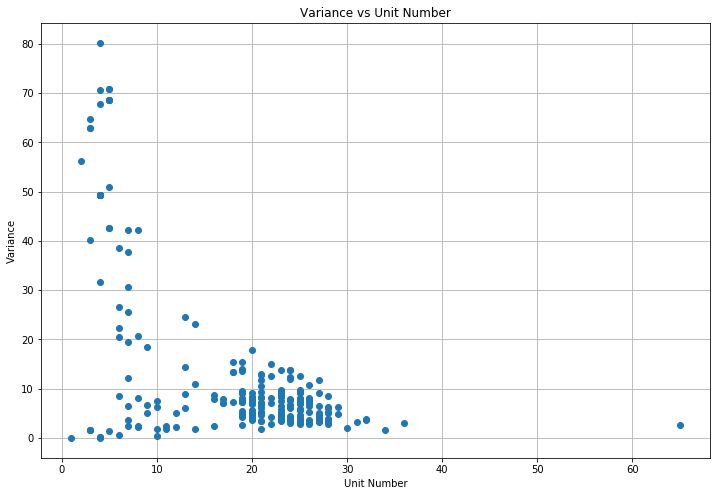

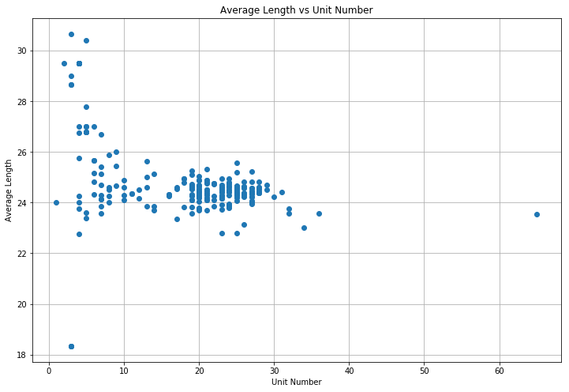

```python
fig = plt.figure(figsize=(12,8))
plt.plot(summary['unit_number'], summary['variance'],'o')
plt.ylabel('Variance')
plt.xlabel('Unit Number')
plt.title('Variance vs Unit Number')
plt.grid(True)
plt.show()
fig = plt.figure(figsize=(12,8))
plt.plot(summary['unit_number'], summary['average_length'],'o')
plt.ylabel('Average Length')
plt.xlabel('Unit Number')
plt.title('Average Length vs Unit Number')
plt.grid(True)
plt.show()
```

*We should use the results with unit number from 18 to 28.*

```python
summary_selected = summary.loc[(summary['unit_number'] >= 18) & (summary['unit_number'] <= 28)]
print(summary_selected)
```

```
             ID  unit_number  variance  average_length
0    SPU_016457         21.0      4.70           24.33
3    SPU_002538         24.0     13.75           24.50
6    SPU_011541         19.0      4.97           24.63
8    SPU_015533         27.0     11.74           23.96
11   SPU_006458         26.0      2.84           24.65
12   SPU_018237         19.0      7.40           23.84
13   SPU_021194         20.0      5.15           24.45
14   SPU_000985         18.0     13.39           24.94
16   SPU_018409         19.0     13.56           25.26
18   SPU_024733         27.0      3.35           24.41
19   SPU_024062         21.0     11.80           24.90
20   SPU_018213         25.0      4.72           24.20
21   SPU_011949         19.0      7.62           24.53
23   SPU_023033         20.0      3.64           24.40
```

[output cut: 49 more lines]

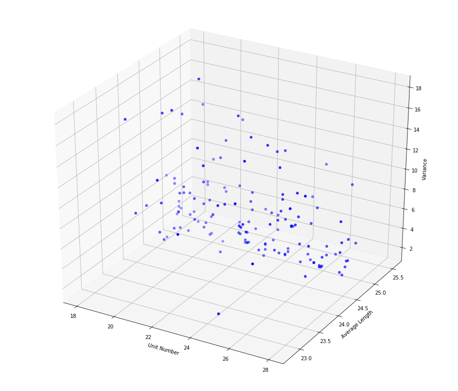

```python
fig = plt.figure(figsize=(16,14))
ax = fig.add_subplot(111, projection='3d')

ax.scatter(summary_selected['unit_number'], summary_selected['average_length'], summary_selected['variance'], c='b', marker='o')

ax.set_xlabel('Unit Number')
ax.set_ylabel('Average Length')
ax.set_zlabel('Variance')

plt.show()
```

# The idea to show the similarity between each sequence

## Method I: Pearson Correlation:

If we have two sequences: sequence_1 = [24,26,27,23,25]; sequence_2 = [23,24,23].

Then we can use two steps to show their correlation with each other

*Step 1*: Since sequence_1 and sequence_2 have different length, we use 0 to fill the shorter one, which makes sequence be sequence_2 = [23,24,23,0,0]

*Step 2*: We can see the corrleation between two sequences

```python
selected_filenames = '../'+summary_selected['ID']+'-tr.txt'
```

```python
repeat_units_in_selected_sequences = pd.DataFrame()
for file in selected_filenames:
    ID = file[3:len(file)-7]
    f = open(file,'r')
    s = f.read()
    result = re.findall("UnitLength=\"(\d+)\"",s)
    result = list(map(int, result))
    df = pd.DataFrame(result)
    repeat_units_in_selected_sequences = pd.concat([repeat_units_in_selected_sequences,df], axis = 1, ignore_index = True)
    f.close()
```

```python
repeat_units_in_selected_sequences.columns = summary_selected['ID']
```

```python
repeat_units_in_selected_sequences = repeat_units_in_selected_sequences.T
```

```python
length_of_selected_sequences = repeat_units_in_selected_sequences.count(axis=1)
length_of_selected_sequences = pd.DataFrame(length_of_selected_sequences)
```

```python
length_of_selected_sequences.columns = ['units_number']
```

Then, we want to use 0 to replace the NULL value in repeat_units_in_selected_sequences.

```python
filled_repeat_units_in_selected_sequences = repeat_units_in_selected_sequences.fillna(0)
```

```python
filled_repeat_units_in_selected_sequences
a = pd.concat([length_of_selected_sequences, filled_repeat_units_in_selected_sequences], axis=1)
a
```

| ID | units_number | 0 | 1 | 2 | 3 | 4 | 5 | 6 | 7 | 8 | ... | 18 | 19 | 20 | 21 | 22 | 23 | 24 | 25 | 26 | 27 |
| --- | --- | --- | --- | --- | --- | --- | --- | --- | --- | --- | --- | --- | --- | --- | --- | --- | --- | --- | --- | --- | --- |
| SPU_016457 | 21 | 21.0 | 24.0 | 24.0 | 24.0 | 24.0 | 21.0 | 24.0 | 23.0 | 28.0 | ... | 24.0 | 27.0 | 22.0 | 0.0 | 0.0 | 0.0 | 0.0 | 0.0 | 0.0 | 0.0 |
| SPU_002538 | 24 | 31.0 | 21.0 | 24.0 | 24.0 | 25.0 | 24.0 | 21.0 | 24.0 | 23.0 | ... | 24.0 | 24.0 | 24.0 | 25.0 | 27.0 | 22.0 | 0.0 | 0.0 | 0.0 | 0.0 |
| SPU_011541 | 19 | 27.0 | 21.0 | 24.0 | 24.0 | 21.0 | 24.0 | 26.0 | 24.0 | 26.0 | ... | 24.0 | 0.0 | 0.0 | 0.0 | 0.0 | 0.0 | 0.0 | 0.0 | 0.0 | 0.0 |
| SPU_015533 | 27 | 15.0 | 27.0 | 21.0 | 24.0 | 24.0 | 25.0 | 24.0 | 21.0 | 24.0 | ... | 24.0 | 24.0 | 24.0 | 24.0 | 25.0 | 24.0 | 24.0 | 24.0 | 22.0 | 0.0 |
| SPU_006458 | 26 | 24.0 | 24.0 | 24.0 | 24.0 | 24.0 | 26.0 | 24.0 | 24.0 | 29.0 | ... | 31.0 | 24.0 | 24.0 | 24.0 | 24.0 | 24.0 | 25.0 | 24.0 | 0.0 | 0.0 |
| SPU_018237 | 19 | 31.0 | 20.0 | 16.0 | 23.0 | 24.0 | 24.0 | 24.0 | 24.0 | 24.0 | ... | 23.0 | 0.0 | 0.0 | 0.0 | 0.0 | 0.0 | 0.0 | 0.0 | 0.0 | 0.0 |
| SPU_021194 | 20 | 23.0 | 21.0 | 24.0 | 24.0 | 24.0 | 32.0 | 26.0 | 24.0 | 24.0 | ... | 24.0 | 23.0 | 0.0 | 0.0 | 0.0 | 0.0 | 0.0 | 0.0 | 0.0 | 0.0 |
| SPU_000985 | 18 | 24.0 | 24.0 | 29.0 | 24.0 | 24.0 | 24.0 | 24.0 | 23.0 | 24.0 | ... | 0.0 | 0.0 | 0.0 | 0.0 | 0.0 | 0.0 | 0.0 | 0.0 | 0.0 | 0.0 |
| SPU_018409 | 19 | 26.0 | 21.0 | 24.0 | 33.0 | 24.0 | 26.0 | 24.0 | 24.0 | 26.0 | ... | 18.0 | 0.0 | 0.0 | 0.0 | 0.0 | 0.0 | 0.0 | 0.0 | 0.0 | 0.0 |
| SPU_024733 | 27 | 21.0 | 24.0 | 24.0 | 24.0 | 24.0 | 26.0 | 24.0 | 24.0 | 29.0 | ... | 31.0 | 24.0 | 24.0 | 24.0 | 24.0 | 24.0 | 25.0 | 24.0 | 22.0 | 0.0 |
| SPU_024062 | 21 | 21.0 | 24.0 | 33.0 | 16.0 | 24.0 | 24.0 | 30.0 | 26.0 | 24.0 | ... | 25.0 | 27.0 | 22.0 | 0.0 | 0.0 | 0.0 | 0.0 | 0.0 | 0.0 | 0.0 |
| SPU_018213 | 25 | 23.0 | 21.0 | 24.0 | 24.0 | 24.0 | 24.0 | 23.0 | 26.0 | 24.0 | ... | 32.0 | 24.0 | 24.0 | 24.0 | 24.0 | 21.0 | 22.0 | 0.0 | 0.0 | 0.0 |
| SPU_011949 | 19 | 24.0 | 26.0 | 24.0 | 24.0 | 25.0 | 24.0 | 21.0 | 24.0 | 24.0 | ... | 18.0 | 0.0 | 0.0 | 0.0 | 0.0 | 0.0 | 0.0 | 0.0 | 0.0 | 0.0 |
| SPU_023033 | 20 | 25.0 | 23.0 | 21.0 | 24.0 | 24.0 | 25.0 | 24.0 | 25.0 | 24.0 | ... | 27.0 | 22.0 | 0.0 | 0.0 | 0.0 | 0.0 | 0.0 | 0.0 | 0.0 | 0.0 |
| SPU_008477 | 23 | 24.0 | 24.0 | 22.0 | 22.0 | 24.0 | 22.0 | 24.0 | 22.0 | 24.0 | ... | 24.0 | 24.0 | 23.0 | 23.0 | 16.0 | 0.0 | 0.0 | 0.0 | 0.0 | 0.0 |
| SPU_028639 | 25 | 24.0 | 24.0 | 19.0 | 21.0 | 24.0 | 24.0 | 26.0 | 25.0 | 24.0 | ... | 24.0 | 24.0 | 24.0 | 24.0 | 25.0 | 31.0 | 18.0 | 0.0 | 0.0 | 0.0 |
| SPU_027815 | 21 | 21.0 | 24.0 | 24.0 | 28.0 | 26.0 | 24.0 | 24.0 | 24.0 | 20.0 | ... | 24.0 | 27.0 | 22.0 | 0.0 | 0.0 | 0.0 | 0.0 | 0.0 | 0.0 | 0.0 |
| SPU_024731 | 27 | 21.0 | 24.0 | 24.0 | 24.0 | 24.0 | 23.0 | 24.0 | 24.0 | 24.0 | ... | 23.0 | 31.0 | 24.0 | 24.0 | 24.0 | 24.0 | 21.0 | 23.0 | 22.0 | 0.0 |
| SPU_007991 | 23 | 23.0 | 21.0 | 24.0 | 24.0 | 25.0 | 24.0 | 18.0 | 24.0 | 26.0 | ... | 24.0 | 25.0 | 24.0 | 27.0 | 26.0 | 0.0 | 0.0 | 0.0 | 0.0 | 0.0 |
| SPU_011156 | 23 | 21.0 | 24.0 | 24.0 | 24.0 | 24.0 | 26.0 | 24.0 | 24.0 | 29.0 | ... | 31.0 | 24.0 | 24.0 | 24.0 | 24.0 | 0.0 | 0.0 | 0.0 | 0.0 | 0.0 |
| SPU_018519 | 28 | 27.0 | 21.0 | 24.0 | 24.0 | 25.0 | 24.0 | 21.0 | 24.0 | 24.0 | ... | 31.0 | 25.0 | 24.0 | 24.0 | 24.0 | 25.0 | 24.0 | 24.0 | 27.0 | 22.0 |
| SPU_006952 | 25 | 22.0 | 26.0 | 24.0 | 24.0 | 24.0 | 25.0 | 24.0 | 35.0 | 24.0 | ... | 24.0 | 24.0 | 26.0 | 25.0 | 26.0 | 31.0 | 24.0 | 0.0 | 0.0 | 0.0 |
| SPU_014266 | 18 | 32.0 | 21.0 | 24.0 | 24.0 | 25.0 | 24.0 | 21.0 | 24.0 | 24.0 | ... | 0.0 | 0.0 | 0.0 | 0.0 | 0.0 | 0.0 | 0.0 | 0.0 | 0.0 | 0.0 |
| SPU_021425 | 24 | 23.0 | 22.0 | 21.0 | 24.0 | 24.0 | 24.0 | 16.0 | 23.0 | 26.0 | ... | 26.0 | 24.0 | 24.0 | 24.0 | 23.0 | 24.0 | 0.0 | 0.0 | 0.0 | 0.0 |
| SPU_004791 | 24 | 21.0 | 24.0 | 24.0 | 24.0 | 24.0 | 26.0 | 24.0 | 24.0 | 29.0 | ... | 30.0 | 24.0 | 24.0 | 24.0 | 24.0 | 24.0 | 0.0 | 0.0 | 0.0 | 0.0 |
| SPU_017530 | 23 | 21.0 | 24.0 | 24.0 | 24.0 | 24.0 | 21.0 | 24.0 | 24.0 | 25.0 | ... | 24.0 | 24.0 | 25.0 | 27.0 | 22.0 | 0.0 | 0.0 | 0.0 | 0.0 | 0.0 |
| SPU_008228 | 21 | 23.0 | 33.0 | 24.0 | 24.0 | 24.0 | 24.0 | 24.0 | 21.0 | 25.0 | ... | 24.0 | 31.0 | 18.0 | 0.0 | 0.0 | 0.0 | 0.0 | 0.0 | 0.0 | 0.0 |
| SPU_018211 | 19 | 23.0 | 21.0 | 24.0 | 24.0 | 24.0 | 24.0 | 23.0 | 26.0 | 24.0 | ... | 32.0 | 0.0 | 0.0 | 0.0 | 0.0 | 0.0 | 0.0 | 0.0 | 0.0 | 0.0 |
| SPU_024404 | 21 | 21.0 | 24.0 | 24.0 | 23.0 | 24.0 | 23.0 | 24.0 | 26.0 | 24.0 | ... | 25.0 | 31.0 | 18.0 | 0.0 | 0.0 | 0.0 | 0.0 | 0.0 | 0.0 | 0.0 |
| SPU_019309 | 24 | 24.0 | 24.0 | 25.0 | 24.0 | 21.0 | 24.0 | 24.0 | 26.0 | 26.0 | ... | 24.0 | 25.0 | 24.0 | 24.0 | 27.0 | 22.0 | 0.0 | 0.0 | 0.0 | 0.0 |
| ... | ... | ... | ... | ... | ... | ... | ... | ... | ... | ... | ... | ... | ... | ... | ... | ... | ... | ... | ... | ... | ... |
| SPU_015066 | 24 | 26.0 | 21.0 | 24.0 | 24.0 | 25.0 | 24.0 | 21.0 | 24.0 | 26.0 | ... | 24.0 | 24.0 | 24.0 | 25.0 | 24.0 | 22.0 | 0.0 | 0.0 | 0.0 | 0.0 |
| SPU_008278 | 23 | 21.0 | 24.0 | 34.0 | 16.0 | 24.0 | 24.0 | 24.0 | 23.0 | 27.0 | ... | 24.0 | 24.0 | 25.0 | 31.0 | 18.0 | 0.0 | 0.0 | 0.0 | 0.0 | 0.0 |
| SPU_018410 | 25 | 24.0 | 24.0 | 22.0 | 21.0 | 24.0 | 24.0 | 26.0 | 24.0 | 23.0 | ... | 24.0 | 24.0 | 24.0 | 24.0 | 25.0 | 27.0 | 22.0 | 0.0 | 0.0 | 0.0 |
| SPU_030114 | 19 | 21.0 | 24.0 | 24.0 | 25.0 | 24.0 | 21.0 | 24.0 | 23.0 | 29.0 | ... | 25.0 | 0.0 | 0.0 | 0.0 | 0.0 | 0.0 | 0.0 | 0.0 | 0.0 | 0.0 |
| SPU_004360 | 28 | 29.0 | 21.0 | 24.0 | 24.0 | 24.0 | 24.0 | 26.0 | 24.0 | 24.0 | ... | 24.0 | 31.0 | 24.0 | 24.0 | 24.0 | 24.0 | 24.0 | 25.0 | 24.0 | 22.0 |
| SPU_001877 | 25 | 21.0 | 24.0 | 24.0 | 25.0 | 24.0 | 21.0 | 24.0 | 23.0 | 28.0 | ... | 31.0 | 24.0 | 24.0 | 24.0 | 25.0 | 27.0 | 22.0 | 0.0 | 0.0 | 0.0 |
| SPU_027162 | 28 | 32.0 | 21.0 | 24.0 | 24.0 | 24.0 | 24.0 | 24.0 | 26.0 | 25.0 | ... | 23.0 | 26.0 | 31.0 | 24.0 | 24.0 | 24.0 | 24.0 | 24.0 | 25.0 | 24.0 |
| SPU_005950 | 23 | 24.0 | 18.0 | 21.0 | 24.0 | 24.0 | 25.0 | 24.0 | 21.0 | 24.0 | ... | 24.0 | 24.0 | 25.0 | 31.0 | 18.0 | 0.0 | 0.0 | 0.0 | 0.0 | 0.0 |
| SPU_005850 | 23 | 21.0 | 24.0 | 24.0 | 25.0 | 24.0 | 21.0 | 24.0 | 23.0 | 27.0 | ... | 24.0 | 24.0 | 25.0 | 27.0 | 22.0 | 0.0 | 0.0 | 0.0 | 0.0 | 0.0 |
| SPU_021420 | 23 | 19.0 | 24.0 | 21.0 | 24.0 | 24.0 | 24.0 | 24.0 | 15.0 | 26.0 | ... | 24.0 | 24.0 | 23.0 | 27.0 | 22.0 | 0.0 | 0.0 | 0.0 | 0.0 | 0.0 |
| SPU_027721 | 22 | 21.0 | 24.0 | 24.0 | 25.0 | 24.0 | 21.0 | 24.0 | 18.0 | 24.0 | ... | 24.0 | 24.0 | 25.0 | 22.0 | 0.0 | 0.0 | 0.0 | 0.0 | 0.0 | 0.0 |
| SPU_018534 | 22 | 24.0 | 24.0 | 24.0 | 24.0 | 24.0 | 25.0 | 24.0 | 23.0 | 24.0 | ... | 24.0 | 26.0 | 27.0 | 22.0 | 0.0 | 0.0 | 0.0 | 0.0 | 0.0 | 0.0 |
| SPU_004311 | 25 | 23.0 | 32.0 | 21.0 | 24.0 | 24.0 | 25.0 | 24.0 | 21.0 | 24.0 | ... | 24.0 | 24.0 | 24.0 | 25.0 | 24.0 | 27.0 | 22.0 | 0.0 | 0.0 | 0.0 |
| SPU_008456 | 27 | 23.0 | 21.0 | 24.0 | 24.0 | 24.0 | 24.0 | 24.0 | 26.0 | 24.0 | ... | 23.0 | 26.0 | 31.0 | 24.0 | 24.0 | 24.0 | 24.0 | 24.0 | 22.0 | 0.0 |
| SPU_009173 | 23 | 21.0 | 24.0 | 24.0 | 25.0 | 24.0 | 21.0 | 24.0 | 23.0 | 27.0 | ... | 24.0 | 24.0 | 25.0 | 27.0 | 22.0 | 0.0 | 0.0 | 0.0 | 0.0 | 0.0 |
| SPU_017529 | 20 | 21.0 | 24.0 | 24.0 | 24.0 | 24.0 | 21.0 | 24.0 | 31.0 | 23.0 | ... | 25.0 | 22.0 | 0.0 | 0.0 | 0.0 | 0.0 | 0.0 | 0.0 | 0.0 | 0.0 |
| SPU_020644 | 24 | 24.0 | 28.0 | 24.0 | 24.0 | 25.0 | 24.0 | 21.0 | 24.0 | 24.0 | ... | 24.0 | 24.0 | 24.0 | 25.0 | 27.0 | 22.0 | 0.0 | 0.0 | 0.0 | 0.0 |
| SPU_030132 | 22 | 21.0 | 24.0 | 24.0 | 24.0 | 24.0 | 26.0 | 24.0 | 24.0 | 24.0 | ... | 24.0 | 24.0 | 24.0 | 24.0 | 0.0 | 0.0 | 0.0 | 0.0 | 0.0 | 0.0 |
| SPU_005831 | 21 | 24.0 | 24.0 | 24.0 | 25.0 | 24.0 | 26.0 | 24.0 | 26.0 | 26.0 | ... | 24.0 | 23.0 | 25.0 | 0.0 | 0.0 | 0.0 | 0.0 | 0.0 | 0.0 | 0.0 |
| SPU_011823 | 21 | 24.0 | 24.0 | 25.0 | 24.0 | 24.0 | 25.0 | 24.0 | 24.0 | 24.0 | ... | 24.0 | 31.0 | 18.0 | 0.0 | 0.0 | 0.0 | 0.0 | 0.0 | 0.0 | 0.0 |
| SPU_024868 | 25 | 31.0 | 21.0 | 24.0 | 24.0 | 25.0 | 24.0 | 21.0 | 24.0 | 24.0 | ... | 31.0 | 29.0 | 24.0 | 24.0 | 24.0 | 25.0 | 22.0 | 0.0 | 0.0 | 0.0 |
| SPU_014191 | 23 | 31.0 | 21.0 | 24.0 | 24.0 | 25.0 | 24.0 | 21.0 | 24.0 | 26.0 | ... | 24.0 | 24.0 | 24.0 | 25.0 | 22.0 | 0.0 | 0.0 | 0.0 | 0.0 | 0.0 |
| SPU_024815 | 21 | 23.0 | 25.0 | 21.0 | 24.0 | 24.0 | 25.0 | 24.0 | 25.0 | 24.0 | ... | 25.0 | 31.0 | 18.0 | 0.0 | 0.0 | 0.0 | 0.0 | 0.0 | 0.0 | 0.0 |
| SPU_024385 | 24 | 32.0 | 21.0 | 24.0 | 24.0 | 25.0 | 24.0 | 21.0 | 24.0 | 23.0 | ... | 24.0 | 24.0 | 24.0 | 25.0 | 31.0 | 18.0 | 0.0 | 0.0 | 0.0 | 0.0 |
| SPU_021162 | 20 | 22.0 | 21.0 | 24.0 | 24.0 | 24.0 | 24.0 | 15.0 | 26.0 | 29.0 | ... | 24.0 | 21.0 | 0.0 | 0.0 | 0.0 | 0.0 | 0.0 | 0.0 | 0.0 | 0.0 |
| SPU_011539 | 20 | 15.0 | 24.0 | 24.0 | 25.0 | 24.0 | 21.0 | 24.0 | 26.0 | 24.0 | ... | 27.0 | 22.0 | 0.0 | 0.0 | 0.0 | 0.0 | 0.0 | 0.0 | 0.0 | 0.0 |
| SPU_022909 | 24 | 24.0 | 24.0 | 24.0 | 24.0 | 23.0 | 26.0 | 24.0 | 24.0 | 28.0 | ... | 24.0 | 24.0 | 24.0 | 21.0 | 27.0 | 22.0 | 0.0 | 0.0 | 0.0 | 0.0 |
| SPU_030098 | 20 | 24.0 | 24.0 | 25.0 | 24.0 | 21.0 | 24.0 | 26.0 | 24.0 | 26.0 | ... | 24.0 | 24.0 | 0.0 | 0.0 | 0.0 | 0.0 | 0.0 | 0.0 | 0.0 | 0.0 |
| SPU_026296 | 25 | 24.0 | 24.0 | 22.0 | 26.0 | 20.0 | 24.0 | 22.0 | 22.0 | 21.0 | ... | 23.0 | 26.0 | 21.0 | 24.0 | 24.0 | 23.0 | 22.0 | 0.0 | 0.0 | 0.0 |
| SPU_016468 | 27 | 21.0 | 24.0 | 24.0 | 24.0 | 24.0 | 15.0 | 26.0 | 24.0 | 23.0 | ... | 26.0 | 24.0 | 24.0 | 24.0 | 23.0 | 25.0 | 24.0 | 27.0 | 22.0 | 0.0 |

153 rows × 29 columns

```python
a = a.sort_values('units_number')
```

```python
a.T.corr()
```

| ID | SPU_002224 | SPU_000985 | SPU_019916 | SPU_014266 | SPU_020666 | SPU_011536 | SPU_014932 | SPU_020257 | SPU_027445 | SPU_009223 | ... | SPU_018519 | SPU_004360 | SPU_021362 | SPU_027162 | SPU_013676 | SPU_026200 | SPU_028576 | SPU_005088 | SPU_009037 | SPU_003684 |
| --- | --- | --- | --- | --- | --- | --- | --- | --- | --- | --- | --- | --- | --- | --- | --- | --- | --- | --- | --- | --- | --- |
| SPU_002224 | 1.000000 | 1.000000 | 0.947600 | 0.957346 | 0.896832 | 0.918719 | 0.882387 | 0.838775 | 0.882387 | 0.868974 | ... | -0.147268 | 0.042946 | 0.085652 | -0.092522 | -0.160338 | -0.086783 | -0.164044 | -0.052129 | -0.328176 | -0.294384 |
| SPU_000985 | 1.000000 | 1.000000 | 0.947600 | 0.957346 | 0.896832 | 0.918719 | 0.882387 | 0.838775 | 0.882387 | 0.868974 | ... | -0.147268 | 0.042946 | 0.085652 | -0.092522 | -0.160338 | -0.086783 | -0.164044 | -0.052129 | -0.328176 | -0.294384 |
| SPU_019916 | 0.947600 | 0.947600 | 1.000000 | 0.964613 | 0.872994 | 0.893565 | 0.869490 | 0.829201 | 0.869490 | 0.857603 | ... | -0.116044 | 0.055828 | 0.056358 | 0.071379 | -0.066150 | -0.208081 | -0.076349 | -0.035951 | -0.397951 | -0.208821 |
| SPU_014266 | 0.957346 | 0.957346 | 0.964613 | 1.000000 | 0.906715 | 0.915272 | 0.885022 | 0.831489 | 0.885022 | 0.870955 | ... | -0.094642 | 0.050970 | 0.072075 | 0.062649 | -0.038945 | -0.190438 | -0.099228 | -0.005720 | -0.350959 | -0.234624 |
| SPU_020666 | 0.896832 | 0.896832 | 0.872994 | 0.906715 | 1.000000 | 0.982896 | 0.981454 | 0.964490 | 0.981454 | 0.974188 | ... | 0.072671 | -0.029456 | 0.295186 | -0.107654 | -0.011922 | -0.130395 | 0.004144 | -0.011027 | -0.277944 | -0.148129 |
| SPU_011536 | 0.918719 | 0.918719 | 0.893565 | 0.915272 | 0.982896 | 1.000000 | 0.972549 | 0.951771 | 0.972549 | 0.965176 | ... | 0.054012 | -0.023803 | 0.247208 | -0.087034 | -0.048745 | -0.163999 | -0.013218 | -0.050442 | -0.303393 | -0.166159 |
| SPU_014932 | 0.882387 | 0.882387 | 0.869490 | 0.885022 | 0.981454 | 0.972549 | 1.000000 | 0.949295 | 1.000000 | 0.949913 | ... | 0.043195 | -0.032538 | 0.265515 | -0.092437 | -0.009542 | -0.146624 | -0.012463 | -0.044008 | -0.283921 | -0.161711 |
| SPU_020257 | 0.838775 | 0.838775 | 0.829201 | 0.831489 | 0.964490 | 0.951771 | 0.949295 | 1.000000 | 0.949295 | 0.952358 | ... | 0.097976 | -0.101801 | 0.331619 | -0.142299 | -0.020726 | -0.123453 | 0.012449 | -0.083859 | -0.223062 | -0.132068 |
| SPU_027445 | 0.882387 | 0.882387 | 0.869490 | 0.885022 | 0.981454 | 0.972549 | 1.000000 | 0.949295 | 1.000000 | 0.949913 | ... | 0.043195 | -0.032538 | 0.265515 | -0.092437 | -0.009542 | -0.146624 | -0.012463 | -0.044008 | -0.283921 | -0.161711 |
| SPU_009223 | 0.868974 | 0.868974 | 0.857603 | 0.870955 | 0.974188 | 0.965176 | 0.949913 | 0.952358 | 0.949913 | 1.000000 | ... | 0.090333 | -0.033531 | 0.372414 | -0.091642 | 0.005644 | -0.125783 | 0.011106 | -0.034026 | -0.299543 | -0.149279 |
| SPU_018211 | 0.830206 | 0.830206 | 0.850760 | 0.844201 | 0.970298 | 0.960000 | 0.954299 | 0.978953 | 0.954299 | 0.964812 | ... | 0.173822 | -0.048518 | 0.338712 | -0.065321 | 0.003658 | -0.177187 | 0.102825 | -0.069291 | -0.300709 | -0.050689 |
| SPU_030096 | 0.909500 | 0.909500 | 0.900898 | 0.914137 | 0.982370 | 0.976319 | 0.959651 | 0.961048 | 0.959651 | 0.969423 | ... | 0.095230 | 0.031416 | 0.270744 | -0.049395 | -0.018582 | -0.113225 | 0.050168 | -0.073052 | -0.306063 | -0.103102 |
| SPU_024429 | 0.916660 | 0.916660 | 0.935464 | 0.936920 | 0.949775 | 0.964811 | 0.936366 | 0.919823 | 0.936366 | 0.915339 | ... | 0.094630 | 0.024596 | 0.164206 | 0.014537 | -0.073741 | -0.226381 | 0.057356 | -0.081395 | -0.377923 | -0.083173 |
| SPU_007790 | 0.919885 | 0.919885 | 0.919754 | 0.935047 | 0.981917 | 0.969418 | 0.955427 | 0.956434 | 0.955427 | 0.954812 | ... | -0.005826 | -0.064987 | 0.270822 | -0.108910 | -0.015589 | -0.165099 | -0.057973 | 0.007073 | -0.262770 | -0.203806 |
| SPU_018237 | 0.874832 | 0.874832 | 0.899236 | 0.914162 | 0.967615 | 0.968418 | 0.952461 | 0.917665 | 0.952461 | 0.953973 | ... | 0.133619 | 0.057860 | 0.270418 | 0.027904 | 0.022936 | -0.183192 | 0.092184 | -0.033095 | -0.357046 | -0.062962 |
| SPU_030114 | 0.885595 | 0.885595 | 0.867387 | 0.885427 | 0.983249 | 0.983025 | 0.985674 | 0.954284 | 0.985674 | 0.967741 | ... | 0.069822 | -0.037878 | 0.316345 | -0.115611 | 0.007583 | -0.151493 | 0.003933 | -0.039430 | -0.262434 | -0.152934 |
| SPU_018409 | 0.911669 | 0.911669 | 0.919468 | 0.941216 | 0.971905 | 0.960136 | 0.940377 | 0.923679 | 0.940377 | 0.946845 | ... | 0.014986 | -0.021234 | 0.224069 | -0.055210 | -0.015301 | -0.184335 | -0.020758 | 0.000928 | -0.307536 | -0.169242 |
| SPU_011949 | 0.925058 | 0.925058 | 0.928430 | 0.943356 | 0.982933 | 0.973053 | 0.957205 | 0.950020 | 0.957205 | 0.956875 | ... | 0.015896 | -0.053369 | 0.242807 | -0.083953 | -0.012257 | -0.180931 | -0.031468 | 0.024812 | -0.287697 | -0.179951 |
| SPU_011541 | 0.904176 | 0.904176 | 0.889454 | 0.910188 | 0.978919 | 0.996978 | 0.968120 | 0.944013 | 0.968120 | 0.961932 | ... | 0.102591 | 0.010468 | 0.251586 | -0.046899 | -0.046193 | -0.178306 | 0.038198 | -0.069107 | -0.336716 | -0.116862 |
| SPU_023936 | 0.783631 | 0.783631 | 0.762544 | 0.784807 | 0.850462 | 0.850697 | 0.821578 | 0.828619 | 0.821578 | 0.838155 | ... | 0.114815 | 0.325966 | 0.365067 | -0.025937 | -0.072846 | 0.208484 | 0.183163 | -0.060356 | -0.099050 | 0.013386 |
| SPU_021194 | 0.832510 | 0.832510 | 0.807797 | 0.831975 | 0.905248 | 0.904578 | 0.875085 | 0.883633 | 0.875085 | 0.892056 | ... | 0.109146 | 0.249813 | 0.363383 | -0.048012 | -0.065271 | 0.134543 | 0.143325 | -0.063995 | -0.146452 | -0.025858 |
| SPU_024204 | 0.822857 | 0.822857 | 0.789600 | 0.815364 | 0.904006 | 0.918292 | 0.872650 | 0.892075 | 0.872650 | 0.891421 | ... | 0.104181 | 0.151270 | 0.379169 | -0.107841 | -0.069919 | 0.073149 | 0.108996 | -0.050997 | -0.121182 | -0.056201 |
| SPU_030098 | 0.839809 | 0.839809 | 0.814741 | 0.834871 | 0.907817 | 0.924610 | 0.898478 | 0.880957 | 0.898478 | 0.891951 | ... | 0.094820 | 0.208188 | 0.317504 | -0.055658 | -0.067342 | 0.086908 | 0.117703 | -0.039053 | -0.144863 | -0.053144 |
| SPU_002442 | 0.822797 | 0.822797 | 0.808916 | 0.817550 | 0.913578 | 0.916440 | 0.922471 | 0.896003 | 0.922471 | 0.894343 | ... | 0.098195 | 0.181943 | 0.353622 | -0.080341 | -0.026073 | 0.080779 | 0.120412 | -0.055988 | -0.119436 | -0.048254 |
| SPU_014041 | 0.824930 | 0.824930 | 0.824879 | 0.844965 | 0.908191 | 0.922847 | 0.897455 | 0.872405 | 0.897455 | 0.892210 | ... | 0.198447 | 0.228925 | 0.340710 | 0.023830 | -0.059135 | 0.008056 | 0.221661 | -0.064818 | -0.226159 | 0.047745 |
| SPU_023033 | 0.822164 | 0.822164 | 0.807857 | 0.831903 | 0.919221 | 0.925368 | 0.899031 | 0.890492 | 0.899031 | 0.907660 | ... | 0.159700 | 0.200314 | 0.366352 | -0.037333 | -0.038294 | 0.064224 | 0.168790 | -0.032305 | -0.166141 | -0.002354 |
| SPU_018928 | 0.836021 | 0.836021 | 0.814738 | 0.832021 | 0.920507 | 0.920830 | 0.922406 | 0.893692 | 0.922406 | 0.901689 | ... | 0.089603 | 0.187127 | 0.366050 | -0.076884 | -0.030821 | 0.094291 | 0.111096 | -0.023297 | -0.116220 | -0.062219 |
| SPU_023193 | 0.831434 | 0.831434 | 0.822032 | 0.826089 | 0.913082 | 0.911598 | 0.924631 | 0.897162 | 0.924631 | 0.896560 | ... | 0.089539 | 0.161277 | 0.401670 | -0.083925 | -0.035946 | 0.062146 | 0.109591 | -0.068230 | -0.133900 | -0.056947 |
| SPU_017529 | 0.818627 | 0.818627 | 0.803336 | 0.817923 | 0.915126 | 0.911240 | 0.929976 | 0.892712 | 0.929976 | 0.886822 | ... | 0.087585 | 0.171047 | 0.334220 | -0.068225 | -0.028424 | 0.072290 | 0.113616 | -0.059011 | -0.144486 | -0.051913 |
| SPU_025136 | 0.774740 | 0.774740 | 0.764495 | 0.777207 | 0.881161 | 0.895287 | 0.879014 | 0.877303 | 0.879014 | 0.882985 | ... | 0.134954 | 0.150920 | 0.300888 | -0.031007 | -0.010544 | 0.068693 | 0.136409 | -0.094547 | -0.106030 | -0.027894 |
| ... | ... | ... | ... | ... | ... | ... | ... | ... | ... | ... | ... | ... | ... | ... | ... | ... | ... | ... | ... | ... | ... |
| SPU_030136 | 0.197947 | 0.197947 | 0.212347 | 0.236076 | 0.322908 | 0.301960 | 0.309163 | 0.339209 | 0.309163 | 0.316736 | ... | 0.279973 | 0.234722 | 0.245359 | 0.122850 | -0.125191 | 0.205327 | 0.389940 | 0.177239 | 0.032823 | 0.043352 |
| SPU_011454 | 0.277414 | 0.277414 | 0.273091 | 0.259722 | 0.368903 | 0.355580 | 0.357822 | 0.409385 | 0.357822 | 0.362296 | ... | 0.011749 | 0.026509 | 0.215289 | -0.124542 | -0.089610 | 0.249763 | 0.092981 | 0.307745 | 0.223456 | -0.232181 |
| SPU_027164 | 0.333968 | 0.333968 | 0.320862 | 0.341076 | 0.393211 | 0.381730 | 0.384888 | 0.365173 | 0.384888 | 0.384448 | ... | -0.037324 | 0.205861 | 0.145469 | -0.008200 | -0.144494 | 0.273307 | 0.031276 | 0.273197 | 0.107664 | -0.308188 |
| SPU_006458 | 0.321405 | 0.321405 | 0.325029 | 0.321454 | 0.424894 | 0.425303 | 0.414399 | 0.428792 | 0.414399 | 0.443379 | ... | 0.143362 | 0.189681 | 0.306535 | 0.021118 | -0.160813 | 0.194163 | 0.267535 | 0.233573 | 0.001819 | -0.102826 |
| SPU_000428 | 0.326153 | 0.326153 | 0.307520 | 0.318738 | 0.439911 | 0.435532 | 0.428819 | 0.446831 | 0.428819 | 0.456085 | ... | 0.134321 | 0.163702 | 0.349202 | -0.017606 | -0.149004 | 0.227023 | 0.235859 | 0.242297 | 0.059516 | -0.130889 |
| SPU_015029 | 0.367104 | 0.367104 | 0.373686 | 0.375214 | 0.407179 | 0.405799 | 0.404335 | 0.405768 | 0.404335 | 0.404971 | ... | 0.018577 | 0.175084 | 0.056589 | 0.065501 | -0.186332 | 0.192242 | 0.097385 | 0.224838 | 0.008757 | -0.245390 |
| SPU_008456 | 0.165032 | 0.165032 | 0.180176 | 0.196441 | 0.201782 | 0.193809 | 0.203595 | 0.215529 | 0.203595 | 0.197355 | ... | 0.269683 | 0.297150 | 0.188157 | 0.329960 | 0.280329 | 0.310178 | 0.239391 | 0.217297 | 0.320156 | -0.246267 |
| SPU_016468 | 0.227187 | 0.227187 | 0.216614 | 0.173911 | 0.266791 | 0.239910 | 0.289398 | 0.280244 | 0.289398 | 0.260274 | ... | 0.268187 | 0.274764 | 0.177614 | 0.002059 | 0.197570 | 0.369984 | 0.219782 | 0.259670 | 0.163976 | -0.235081 |
| SPU_008267 | 0.202606 | 0.202606 | 0.222237 | 0.233544 | 0.255585 | 0.245479 | 0.254714 | 0.273952 | 0.254714 | 0.252243 | ... | 0.301068 | 0.210154 | 0.202838 | 0.337094 | 0.289736 | 0.214881 | 0.236413 | 0.220971 | 0.284881 | -0.240461 |
| SPU_015533 | 0.237436 | 0.237436 | 0.200918 | 0.178326 | 0.251845 | 0.254658 | 0.258042 | 0.284017 | 0.258042 | 0.207327 | ... | 0.114237 | 0.049168 | 0.223888 | -0.157908 | 0.177345 | 0.296564 | 0.037825 | 0.359059 | 0.398900 | -0.373640 |
| SPU_024733 | 0.198884 | 0.198884 | 0.175936 | 0.185939 | 0.325517 | 0.320645 | 0.315088 | 0.341689 | 0.315088 | 0.350661 | ... | 0.374730 | 0.177007 | 0.420165 | -0.017869 | 0.282450 | 0.282791 | 0.286382 | 0.271321 | 0.219590 | -0.217218 |
| SPU_024731 | 0.259274 | 0.259274 | 0.212263 | 0.221347 | 0.257272 | 0.243261 | 0.250193 | 0.249706 | 0.250193 | 0.248028 | ... | 0.254999 | 0.459569 | 0.278436 | 0.064868 | 0.205548 | 0.547972 | 0.268739 | 0.290216 | 0.322730 | -0.215528 |
| SPU_022911 | 0.245731 | 0.245731 | 0.239114 | 0.250622 | 0.373561 | 0.371637 | 0.359067 | 0.371684 | 0.359067 | 0.394023 | ... | 0.375543 | 0.219551 | 0.373196 | 0.041967 | 0.279771 | 0.243448 | 0.305516 | 0.303533 | 0.166987 | -0.198980 |
| SPU_006164 | 0.265672 | 0.265672 | 0.344353 | 0.297842 | 0.276505 | 0.279777 | 0.267082 | 0.275504 | 0.267082 | 0.282001 | ... | 0.402068 | 0.362857 | 0.152676 | 0.268426 | 0.217352 | 0.140068 | 0.412567 | 0.190960 | -0.044399 | -0.068207 |
| SPU_006611 | 0.063916 | 0.063916 | 0.049756 | 0.057872 | 0.163507 | 0.141239 | 0.149216 | 0.179863 | 0.149216 | 0.198709 | ... | 0.439988 | 0.152581 | 0.496836 | -0.025417 | 0.474660 | 0.277754 | 0.262297 | 0.196219 | 0.278884 | -0.194013 |
| SPU_021415 | 0.206481 | 0.206481 | 0.234755 | 0.235577 | 0.249426 | 0.240936 | 0.251220 | 0.247991 | 0.251220 | 0.248127 | ... | 0.169918 | 0.164262 | 0.158019 | 0.248320 | 0.330537 | 0.229863 | 0.150880 | 0.366520 | 0.329983 | -0.325368 |
| SPU_020527 | 0.210952 | 0.210952 | 0.209533 | 0.209641 | 0.211931 | 0.221260 | 0.227438 | 0.202806 | 0.227438 | 0.190991 | ... | 0.221143 | 0.265123 | 0.145647 | 0.053898 | 0.255702 | 0.257532 | 0.172793 | 0.234142 | 0.159232 | -0.308333 |
| SPU_015303 | 0.073521 | 0.073521 | 0.085237 | 0.108680 | 0.115428 | 0.113486 | 0.107547 | 0.111330 | 0.107547 | 0.100103 | ... | 0.256788 | 0.386449 | 0.204021 | 0.198458 | 0.306248 | 0.421455 | 0.261852 | 0.312092 | 0.434215 | -0.218065 |
| SPU_013470 | 0.202606 | 0.202606 | 0.222237 | 0.233544 | 0.255585 | 0.245479 | 0.254714 | 0.273952 | 0.254714 | 0.252243 | ... | 0.301068 | 0.210154 | 0.202838 | 0.337094 | 0.289736 | 0.214881 | 0.236413 | 0.220971 | 0.284881 | -0.240461 |
| SPU_021395 | 0.153649 | 0.153649 | 0.160561 | 0.150211 | 0.261402 | 0.263077 | 0.252539 | 0.274524 | 0.252539 | 0.289829 | ... | 0.449077 | 0.193223 | 0.370007 | 0.043595 | 0.418499 | 0.214222 | 0.319111 | 0.247027 | 0.183769 | -0.185933 |
| SPU_018519 | -0.147268 | -0.147268 | -0.116044 | -0.094642 | 0.072671 | 0.054012 | 0.043195 | 0.097976 | 0.043195 | 0.090333 | ... | 1.000000 | 0.363758 | 0.417545 | 0.316047 | 0.356858 | 0.122086 | 0.835148 | -0.068038 | -0.035429 | 0.667427 |
| SPU_004360 | 0.042946 | 0.042946 | 0.055828 | 0.050970 | -0.029456 | -0.023803 | -0.032538 | -0.101801 | -0.032538 | -0.033531 | ... | 0.363758 | 1.000000 | 0.039444 | 0.446164 | 0.030722 | 0.652125 | 0.578124 | -0.028785 | 0.009484 | 0.428506 |
| SPU_021362 | 0.085652 | 0.085652 | 0.056358 | 0.072075 | 0.295186 | 0.247208 | 0.265515 | 0.331619 | 0.265515 | 0.372414 | ... | 0.417545 | 0.039444 | 1.000000 | -0.118799 | 0.201733 | 0.195684 | 0.324513 | 0.136329 | 0.220957 | 0.187597 |
| SPU_027162 | -0.092522 | -0.092522 | 0.071379 | 0.062649 | -0.107654 | -0.087034 | -0.092437 | -0.142299 | -0.092437 | -0.091642 | ... | 0.316047 | 0.446164 | -0.118799 | 1.000000 | 0.204716 | -0.054945 | 0.441372 | -0.056362 | -0.020518 | 0.380442 |
| SPU_013676 | -0.160338 | -0.160338 | -0.066150 | -0.038945 | -0.011922 | -0.048745 | -0.009542 | -0.020726 | -0.009542 | 0.005644 | ... | 0.356858 | 0.030722 | 0.201733 | 0.204716 | 1.000000 | 0.062140 | 0.155855 | 0.338068 | 0.382246 | -0.002400 |
| SPU_026200 | -0.086783 | -0.086783 | -0.208081 | -0.190438 | -0.130395 | -0.163999 | -0.146624 | -0.123453 | -0.146624 | -0.125783 | ... | 0.122086 | 0.652125 | 0.195684 | -0.054945 | 0.062140 | 1.000000 | 0.236121 | 0.133558 | 0.515269 | 0.101816 |
| SPU_028576 | -0.164044 | -0.164044 | -0.076349 | -0.099228 | 0.004144 | -0.013218 | -0.012463 | 0.012449 | -0.012463 | 0.011106 | ... | 0.835148 | 0.578124 | 0.324513 | 0.441372 | 0.155855 | 0.236121 | 1.000000 | -0.027618 | -0.117787 | 0.858861 |
| SPU_005088 | -0.052129 | -0.052129 | -0.035951 | -0.005720 | -0.011027 | -0.050442 | -0.044008 | -0.083859 | -0.044008 | -0.034026 | ... | -0.068038 | -0.028785 | 0.136329 | -0.056362 | 0.338068 | 0.133558 | -0.027618 | 1.000000 | 0.324886 | -0.164944 |
| SPU_009037 | -0.328176 | -0.328176 | -0.397951 | -0.350959 | -0.277944 | -0.303393 | -0.283921 | -0.223062 | -0.283921 | -0.299543 | ... | -0.035429 | 0.009484 | 0.220957 | -0.020518 | 0.382246 | 0.515269 | -0.117787 | 0.324886 | 1.000000 | -0.193030 |
| SPU_003684 | -0.294384 | -0.294384 | -0.208821 | -0.234624 | -0.148129 | -0.166159 | -0.161711 | -0.132068 | -0.161711 | -0.149279 | ... | 0.667427 | 0.428506 | 0.187597 | 0.380442 | -0.002400 | 0.101816 | 0.858861 | -0.164944 | -0.193030 | 1.000000 |

153 rows × 153 columns

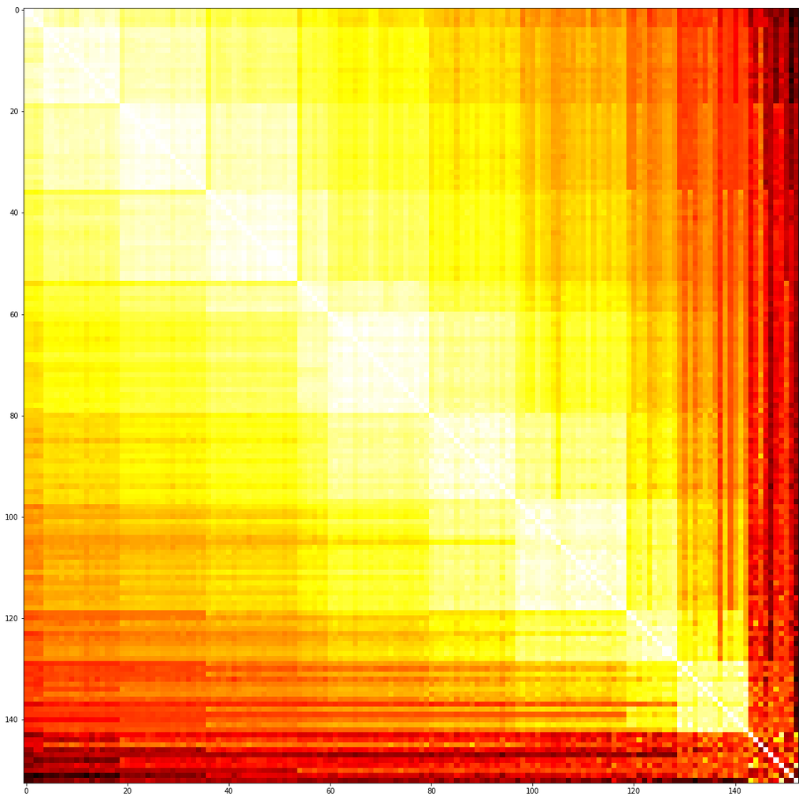

```python
import seaborn as sns
plt.figure(figsize=(20, 20))
plt.imshow(a.T.corr(), cmap='hot', interpolation='nearest')
```

```python
sequence_1 = [24,26,27]
sequence_2 = [23,24,23]
```

```python
import numpy as np
from scipy.stats import pearsonr
r,p = pearsonr(sequence_1,sequence_2)

print(r)

print( p)
```

```
0.18898223650461365
0.8789622816763233
```

Then, for the dataset we have, we can compute the correlation of each two sequence and make a matrix. Using the correlation matrix, we can do cluster and classification of the sequences.

## Conclusion

Heat map is one way to visualize the relationship between each two TLR sequences. From the heat map, we find it is possible to cluster protein sequences through their features (The length of each repeat units). It is a interesting topic waiting for us in the future research.